# PROGETTO DATA MINING: Text mining Sherlock Holmes

Giuditta ADEZIO, Agnese BELLONI, Luca MARTEGANI

2024-04-24

Questo progetto mira a un’analisi approfondita dei libri di Sherlock Holmes di Arthur Conann Doyle attraverso tecniche di text mining.

## ANALISI ESPLORATIVA CON MONDO TIDYVERSE

Dopo aver importato alcune library, che ci saranno utili nelle analisi successive, e aver caricato i documenti attraverso la library sherlock presente nella directory di Github riportata nello script, selezioniamo un solo libro per analizzarne i singoli termini. Il libro in questione è “A Study In Scarlet”.

```r
# devtools::install_github("EmilHvitfeldt/sherlock")
library(sherlock)
library(tidyverse)
library(stringr)
library(tidytext)
sherlock::holmes
```

```
## # A tibble: 65,958 × 2
##    text                                 book
##    <chr>                                <chr>
##  1 "A STUDY IN SCARLET"                 A Study In Scarlet
##  2 ""                                   A Study In Scarlet
##  3 "Table of contents"                  A Study In Scarlet
##  4 ""                                   A Study In Scarlet
##  5 "Part I"                             A Study In Scarlet
##  6 "Mr. Sherlock Holmes"                A Study In Scarlet
##  7 "The Science Of Deduction"           A Study In Scarlet
##  8 "The Lauriston Garden Mystery"       A Study In Scarlet
##  9 "What John Rance Had To Tell"        A Study In Scarlet
## 10 "Our Advertisement Brings A Visitor" A Study In Scarlet
## # ℹ 65,948 more rows
```

```r
str(holmes)
```

```
## tibble [65,958 × 2] (S3: tbl_df/tbl/data.frame)
##  $ text: chr [1:65958] "A STUDY IN SCARLET" "" "Table of contents" "" ...
##  $ book: chr [1:65958] "A Study In Scarlet" "A Study In Scarlet" "A Study In Scarlet" "A Study In Scarlet" ...
```

```r
summary(holmes)
```

```
##      text               book
##  Length:65958       Length:65958
##  Class :character   Class :character
##  Mode  :character   Mode  :character
```

```r
head(holmes)
```

```
## # A tibble: 6 × 2
##   text                  book
##   <chr>                 <chr>
## 1 "A STUDY IN SCARLET"  A Study In Scarlet
## 2 ""                    A Study In Scarlet
## 3 "Table of contents"   A Study In Scarlet
## 4 ""                    A Study In Scarlet
## 5 "Part I"              A Study In Scarlet
## 6 "Mr. Sherlock Holmes" A Study In Scarlet
```

```r
unique(holmes$book)
```

```
##  [1] "A Study In Scarlet"
##  [2] "The Sign of the Four"
##  [3] "A Scandal in Bohemia"
##  [4] "The Red-Headed League"
##  [5] "A Case of Identity"
##  [6] "The Boscombe Valley Mystery"
##  [7] "The Five Orange Pips"
##  [8] "The Man with the Twisted Lip"
##  [9] "The Adventure of the Blue Carbuncle"
## [10] "The Adventure of the Speckled Band"
## [11] "The Adventure of the Engineer's Thumb"
## [12] "The Adventure of the Noble Bachelor"
## [13] "The Adventure of the Beryl Coronet"
## [14] "The Adventure of the Copper Beeches"
## [15] "Silver Blaze"
```

[output cut: 33 more lines]

```r
astudyinscarlet <- holmes %>%
                      filter(book == 'A Study In Scarlet')
astudyinscarlet <- astudyinscarlet %>%
                             select(text) %>%
                               mutate(chapter = cumsum(str_detect(text, "^CHAPTER")))
astudyinscarlet %>%
  unnest_tokens(word, text)
```

```
## # A tibble: 43,741 × 2
##    chapter word
##      <int> <chr>
##  1       0 a
##  2       0 study
##  3       0 in
##  4       0 scarlet
##  5       0 table
##  6       0 of
##  7       0 contents
##  8       0 part
##  9       0 i
## 10       0 mr
## # ℹ 43,731 more rows
```

Selezionando una lista di libri di nostro interesse abbiamo quindi ripetuto la stessa cosa che avevamo già fatto per il primo (A Study in Scarlet) mettendo tutti i termini in un tibble con le singole parole, affiancate a ogni libro in cui esse vengono utilizzate.

```r
titles <- c('A Study In Scarlet',"A Scandal in Bohemia",
            "The Adventure of the Devil's Foot", "The Hound of the Baskervilles",
            "The Red-Headed League", "His Last Bow")

books <- list(filter(holmes, book == "A Study In Scarlet"),
              filter(holmes, book == "A Scandal in Bohemia"),
              filter(holmes, book == "The Adventure of the Devil's Foot"),
              filter(holmes, book == "The Hound of the Baskervilles"),
              filter(holmes, book == "The Red-Headed League"),
              filter(holmes, book == "His Last Bow") )

series <- tibble()

for (i in seq_along(titles)) {
  clean <- books[[i]]%>%
    select(text)%>%
    mutate(chapter = cumsum(str_detect(text, "^CHAPTER"))) %>%
    unnest_tokens(word, text) %>%
    mutate(book = titles[i]) %>%
    select(book, everything())

  series <- rbind(series, clean)

}

series
```

```
## # A tibble: 137,558 × 3
##    book               chapter word
##    <chr>                <int> <chr>
##  1 A Study In Scarlet       0 a
##  2 A Study In Scarlet       0 study
##  3 A Study In Scarlet       0 in
##  4 A Study In Scarlet       0 scarlet
##  5 A Study In Scarlet       0 table
##  6 A Study In Scarlet       0 of
##  7 A Study In Scarlet       0 contents
##  8 A Study In Scarlet       0 part
##  9 A Study In Scarlet       0 i
## 10 A Study In Scarlet       0 mr
## # ℹ 137,548 more rows
```

```r
series$book <- factor(series$book, levels = rev(titles))
```

Adesso eseguendo l’azione di eliminazione delle stopwords contiamo quante volte ogni termine viene ripetuto, considerando tutti i libri scelti in precendenza congiuntamente.

```r
numero <- series %>%
  anti_join(stop_words) %>%
    count(word, sort = T)
numero
```

```
## # A tibble: 9,289 × 2
##    word       n
##    <chr>  <int>
##  1 holmes   459
##  2 sir      398
##  3 time     216
##  4 watson   183
##  5 eyes     167
##  6 moor     166
##  7 house    162
##  8 night    161
##  9 henry    147
## 10 hand     131
## # ℹ 9,279 more rows
```

Ne ricaviamo che le parole più utilizzate sono Holmes e Sir che risultano ripetute molte più volte della terza parola in quest’ordine (time).

Rappresentiamo graficamente le parole più utilizzate divise per libro.

```r
library(RColorBrewer)

df <- series %>%
        anti_join(stop_words) %>%
        group_by(book) %>%
        count(word, sort = TRUE) %>%
        top_n(10) %>%
        ungroup() %>%
        mutate(book = factor(book, levels = titles),
              text_order = nrow(.):1)
```

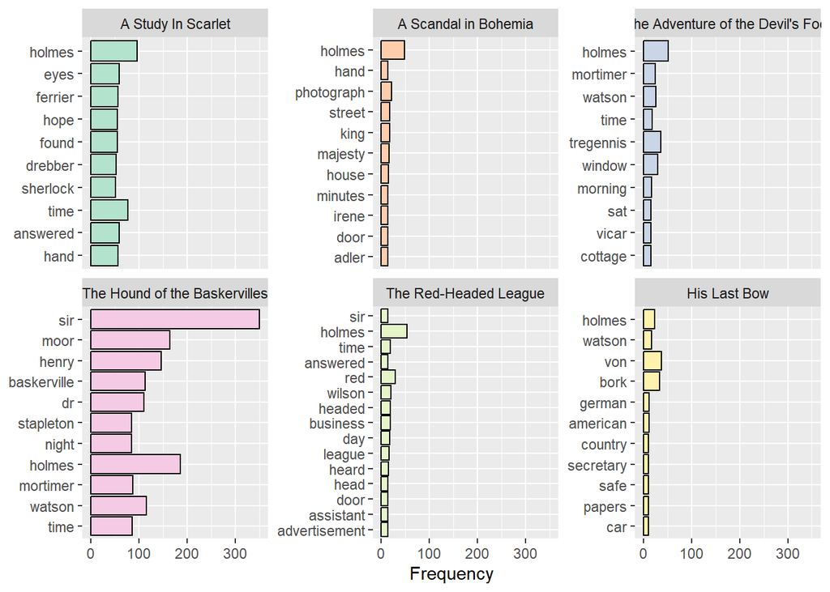

```r
ggplot(df, aes(reorder(word, n), n, fill = book)) +
  geom_bar(stat = "identity", color = 'black') +
  facet_wrap(~ book, scales = "free_y") +
  labs(x = NULL, y = "Frequency") +
  coord_flip()+
  scale_fill_brewer(palette = 'Pastel2') +
  theme(legend.position="none")
```

Essendo la scala utilizzata sulle x uguale per tutti i libri possiamo ben vedere come la frequenza delle parole del libro ‘The Hound of the Baskervilles’ è di molto maggiore rispetto alle parole degli altri libri.

Calcoliamo di seguito le frequenze relative di utilizzo dei termini rispetto a tutti i libri e relativamente a ogni singolo libro.

```r
sherlock_pct <- series %>%
  anti_join(stop_words) %>%
  count(word) %>%
  transmute(word, all_words = n / sum(n))
(frequency <- series %>%
  anti_join(stop_words) %>%
  count(book, word) %>%
  mutate(book_words = n / sum(n)) %>%
  left_join(sherlock_pct) %>%
  arrange(desc(book_words)) %>%
  ungroup())
```

```
## # A tibble: 16,366 × 5
##    book                          word            n book_words all_words
##    <fct>                         <chr>       <int>      <dbl>     <dbl>
##  1 The Hound of the Baskervilles sir           351    0.00806   0.00914
##  2 The Hound of the Baskervilles holmes        186    0.00427   0.0105
##  3 The Hound of the Baskervilles moor          164    0.00377   0.00381
##  4 The Hound of the Baskervilles henry         147    0.00337   0.00337
##  5 The Hound of the Baskervilles watson        116    0.00266   0.00420
##  6 The Hound of the Baskervilles baskerville   113    0.00259   0.00259
##  7 The Hound of the Baskervilles dr            110    0.00253   0.00294
##  8 A Study In Scarlet            holmes         97    0.00223   0.0105
##  9 The Hound of the Baskervilles mortimer       87    0.00200   0.00257
## 10 The Hound of the Baskervilles time           86    0.00197   0.00496
## # ℹ 16,356 more rows
```

Notiamo facilmente da questa tabella che il libro The Hound of the Baskervilles probabilmente è molto più lungo degli altri o ripete molto spesso le stesse parole dal momento che 9 su 10 delle parole in top 10 assoluta appartengono a tale libro, ciò coerentemente con quanto detto riguardo il grafico precedente.

Poi calcoliamo un tibble che riporta la correlazione tra le parole di ogni libro e quelle totali calcolandone anche il pvalue per valutarne la significatività.

```r
(corr <- frequency %>%
        group_by(book) %>%
           summarize(correlation = cor(book_words, all_words),
              p_value = cor.test(book_words, all_words)$p.value) %>%
           arrange(desc(correlation)))
```

```
## # A tibble: 6 × 3
##   book                              correlation   p_value
##   <fct>                                   <dbl>     <dbl>
## 1 The Hound of the Baskervilles           0.904 0
## 2 A Study In Scarlet                      0.800 0
## 3 The Red-Headed League                   0.666 3.90e-198
## 4 The Adventure of the Devil's Foot       0.662 3.63e-213
## 5 A Scandal in Bohemia                    0.628 3.02e-171
## 6 His Last Bow                            0.478 1.09e- 73
```

La correlazione maggiore si ha con le parole di The Hound of the Baskervilles.

```r
top_60 <- frequency %>%
  arrange(desc(book_words)) %>%
  top_n(60)
```

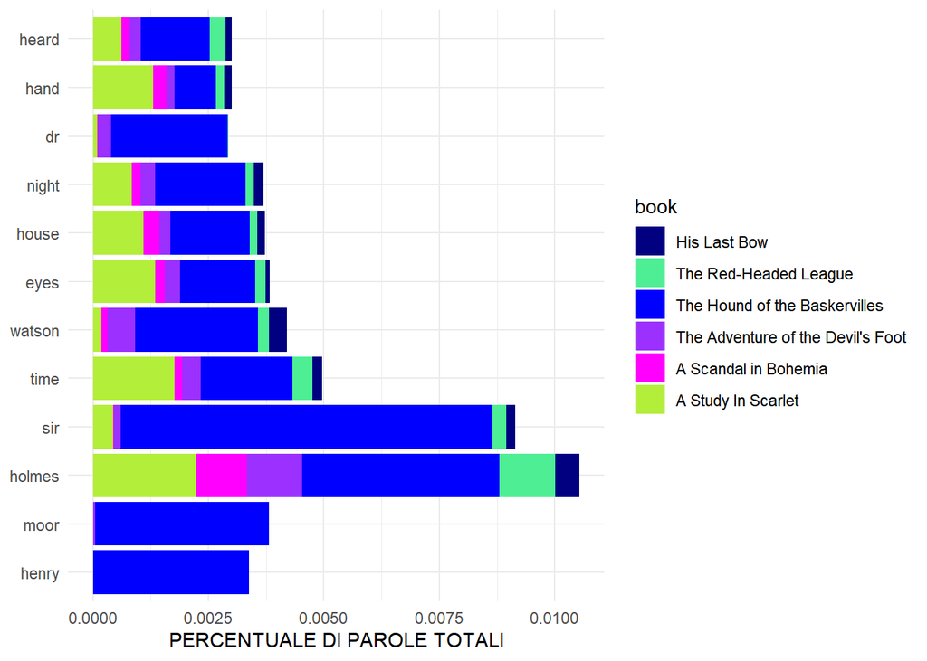

```r
ggplot(top_60, aes(x = reorder(word, -book_words), y = book_words, fill = book)) +
  geom_col() +
  coord_flip() +
  labs(x = NULL, y = "PERCENTUALE DI PAROLE TOTALI") +
  scale_fill_manual(values = c('navy', 'seagreen2', 'blue', 'purple1', 'magenta', 'olivedrab2', 'violet')) +
  theme_minimal()
```

Per concludere quest’analisi iniziale, rappresentiamo graficamente con una wordcloud le parole più usate in questi sei libri scelti.

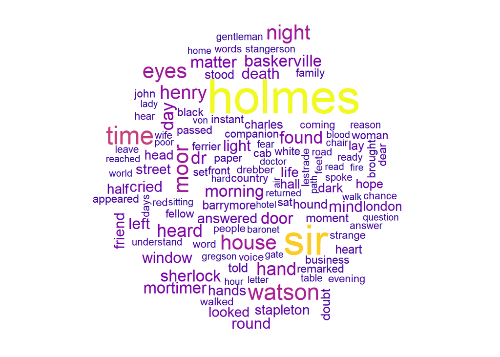

```r
library(wordcloud)
set.seed(123)

wordcloud(numero$word, numero$n, min.freq = 40, colors = viridis::plasma(30))
```

Come precedentemente detto dal grafico si evince che le parole Holmes e sir sono state utilizzate in numero molto più elevato rispetto alle altre. La parola sir ci inizia già a suggerire in che contesto storico è ambientata la storia.

## ANALISI DEL CORPUS CON DOCUMENT TERM

Per la successiva analisi importiamo le library necessarie al text mining senza tidyverse e carichiamo 56 libri, molti dei quali si trovavano anche nella library utilizzata fino a questo momento, come file di testo, per creare in maniera più comoda un Corpus. Abbiamo eseguito la seguente operazione perché dentro la library Sherlock i testi si trovavano tutti nello stesso documento pertanto la document-term non era realizzabile. I 56 libri che fanno parte del corpus sono divisi in macro collezioni.

Le collezioni, ordinate secondo linea temporale, e i rispettivi libri sono: **‘The Adventures of Sherlock Holmes’**: ‘A Scandal in Bohemia’, ‘The Red-Headed League’, ‘A Case of Identity’, ‘The Boscombe Valley Mystery’, ‘The Five Orange Pips’, ‘The Man with the Twisted Lip’, ‘The Adventure of the Blue Carbuncle’, ‘The Adventure of the Speckled Band’, ‘The Adventure of the Engineer’s Thumb’, ‘The Adventure of the Noble Bachelor’, ‘The Adventure of the Beryl Coronet’, ‘The Adventure of the Copper Beeches’ ‘The Memoirs of Sherlock Holmes’: ‘Silver Blaze’, ‘Yellow Face’, ‘The Stoc roker’s Clerk’, ‘The “Gloria Scott”’, ‘The Musgrave Ritual’, ‘The Reigate Puzzle’, ‘The Crooked Man’, ‘The Resident Patient’, ‘The Greek Interpreter’, ‘The Naval Treaty’, ‘The Final Problem’ **‘The Return of Sherlock Holmes’**: ‘The Empty House’, ‘The Norwood Builder’, ‘The Dancing Men’, ‘The Solitary Cyclist’, ‘The Priory School’,‘Black Peter’, ‘Charles Augustus Milverton’, ‘The Six Napoleons’, ‘The Three Students’, ‘The Golden Pince-Nez’, ‘The Missing Three-Quarter’, ‘The Abbey Grange’, ‘The Second Stain’ **‘His Last Bow’**: ‘Wisteria Lodge’, ‘The Cardboard Box’, ‘The Red Circle’, ‘The Bruce-Partington Plans’, ‘The Dying Detective’, ‘Lady Frances Carfax’, ‘The Devil’s Foot’, ‘His Last Bow’ **‘The Case-Book of Sherlock Holmes’**: ‘The Illustrious Client’, ‘The Blanched Soldier’, ‘The Mazarin Stone’, ‘The Three Gables’, ‘The Sussex Vampire’, ‘The Three Garridebs’, ‘Thor Bridge’, ‘The Creeping Man’, ‘The Lion’s Mane’, ‘The Veiled Lodger’, ‘Shoscombe Old Place’, ‘The Retired Colourman’

```r
library(tm)
library(SnowballC)

dati <- Corpus(DirSource("C:\\Users\\giudi\\OneDrive\\Desktop\\uni\\data mining\\sherlock"))
```

A questo punto attuiamo le tecniche base di data mining: togliamo la punteggiatura, i numeri e trasformiamo tutto in minuscolo prima di rimuovere le stopwords di base e gli spazi bianchi.

```r
dati <- tm_map(dati, removePunctuation)
dati <- tm_map(dati, removeNumbers)
dati <- tm_map(dati, content_transformer(tolower))

dati <- tm_map(dati, removeWords, stopwords('english'))
dati <- tm_map(dati, stripWhitespace)
```

Filtriamo le parole nel corpus, trasformato in testo, per cercare a quali parole appartengano alcune radici che nello stemming (riportato in seguito) sono state tagliate in maniera non del tutto corretta, in modo tale da trasformarle successivamente nelle parole giuste.

```r
testo_corpus <- sapply(dati, as.character)
'unlist(str_extract_all(testo_corpus, "\\bspeckl\\w*\\b"))
 unlist(str_extract_all(testo_corpus, "\\blodg\\w*\\b"))
 unlist(str_extract_all(testo_corpus, "\\bnobl\\w*\\b"))
 unlist(str_extract_all(testo_corpus, "\\bboscomb\\w*\\b"))
 unlist(str_extract_all(testo_corpus, "\\bbeech\\w*\\b"))
 unlist(str_extract_all(testo_corpus, "\\bgrang\\w*\\b"))
 unlist(str_extract_all(testo_corpus, "\\bholmesesesd\\w*\\b"))
 unlist(str_extract_all(testo_corpus, "\\bdthe\\w*\\b"))
 unlist(str_extract_all(testo_corpus, "\\bcri\\w*\\b"))
 unlist(str_extract_all(testo_corpus, "\\bdno\\w*\\b"))
 unlist(str_extract_all(testo_corpus, "\\bleav\\w*\\b"))
 unlist(str_extract_all(testo_corpus, "\\bbusi\\w*\\b"))
 unlist(str_extract_all(testo_corpus, "\\bcours\\w*\\b"))
 unlist(str_extract_all(testo_corpus, "\\bpolic\\w*\\b"))
 unlist(str_extract_all(testo_corpus, "\\bdm\\w*\\b")) # ci sono dentro un sacco di  parole ma la più presente è dmy per questo successivamente la trasformeremo in dmy
 unlist(str_extract_all(testo_corpus, "\\banothing\\w*\\b"))
 unlist(str_extract_all(testo_corpus, "\\bmand\\w*\\b"))
 unlist(str_extract_all(testo_corpus, "\\binde\\w*\\b"))
 unlist(str_extract_all(testo_corpus, "\\battent\\w*\\b"))'
```

```
## [1] "unlist(str_extract_all(testo_corpus, \"\\bspeckl\\w*\\b\"))\n unlist(str_extract_all(testo_corpus, \"\\blodg\\w*\\b\"))\n unlist(str_extract_all(testo_corpus, \"\\bnobl\\w*\\b\"))\n unlist(str_extract_all(testo_corpus, \"\\bboscomb\\w*\\b\"))\n unlist(str_extract_all(testo_corpus, \"\\bbeech…
```

```r
# per evitare che li stampasse tutti li abbiamo messi sotto forma di commenti
```

Per migliorare le capacità di text mining passiamo alla fase di stemming per raggruppare tutte le parole con lo stesso significato e ridurre la dimensionalità della matrice che creeremo succesivamente. Come si può ben vedere abbiamo trattato in maniera più accurata le parole più frequenti che erano state tagliate male dallo stemming di R.

```r
dati <- tm_map(dati, stemDocument)

dati <- tm_map(dati, content_transformer(gsub), pattern = 'baskervill',
               replacement = 'baskerville')
dati <- tm_map(dati, content_transformer(gsub), pattern = 'adventur',
               replacement = 'adventure')
dati <- tm_map(dati, content_transformer(gsub), pattern = 'studi',
               replacement = 'study')
dati <- tm_map(dati, content_transformer(gsub), pattern = 'hous',
               replacement = 'house')
dati <- tm_map(dati, content_transformer(gsub), pattern = 'misteri',
               replacement = 'mistery')
dati <- tm_map(dati, content_transformer(gsub), pattern = 'ladi',
               replacement = 'lady')
dati <- tm_map(dati, content_transformer(gsub), pattern = 'priori',
               replacement = 'priority')
dati <- tm_map(dati, content_transformer(gsub), pattern = 'holm',
               replacement = 'holmes')
dati <- tm_map(dati, content_transformer(gsub), pattern = 'speckl',
               replacement = 'speckled')
dati <- tm_map(dati, content_transformer(gsub), pattern = 'mysteri',
               replacement = 'mystery')
dati <- tm_map(dati, content_transformer(gsub), pattern = 'lodg',
               replacement = 'lodge')
dati <- tm_map(dati, content_transformer(gsub), pattern = 'nobl',
               replacement = 'noble')
dati <- tm_map(dati, content_transformer(gsub), pattern = 'boscomb',
               replacement = 'boscombe')
dati <- tm_map(dati, content_transformer(gsub), pattern = 'grang',
               replacement = 'grange')
dati <- tm_map(dati, content_transformer(gsub), pattern = 'leagu',
               replacement = 'league')
dati <- tm_map(dati, content_transformer(gsub), pattern = 'therefor',
               replacement = 'therefore')
dati <- tm_map(dati, content_transformer(gsub), pattern = 'outsid',
               replacement = 'outside')
dati <- tm_map(dati, content_transformer(gsub), pattern = 'forc',
               replacement = 'force')
dati <- tm_map(dati, content_transformer(gsub), pattern = 'terribl',
               replacement = 'terrible')
dati <- tm_map(dati, content_transformer(gsub), pattern = 'littl',
               replacement = 'little')
dati <- tm_map(dati, content_transformer(gsub), pattern = 'everi',
               replacement = 'every')
dati <- tm_map(dati, content_transformer(gsub), pattern = 'howev',
               replacement = 'however')
dati <- tm_map(dati, content_transformer(gsub), pattern = 'cri',
               replacement = 'crime')
dati <- tm_map(dati, content_transformer(gsub), pattern = 'noth',
               replacement = 'nothing')
dati <- tm_map(dati, content_transformer(gsub), pattern = 'holmesesesd',
               replacement = 'holmes')
dati <- tm_map(dati, content_transformer(gsub), pattern = 'possibl',
               replacement = 'possible')
dati <- tm_map(dati, content_transformer(gsub), pattern = 'leav',
               replacement = 'leave')
dati <- tm_map(dati, content_transformer(gsub), pattern = 'leavee',
               replacement = 'leave')
dati <- tm_map(dati, content_transformer(gsub), pattern = 'someth',
               replacement = 'something')
dati <- tm_map(dati, content_transformer(gsub), pattern = 'cour',
               replacement = 'course')
dati <- tm_map(dati, content_transformer(gsub), pattern = 'coursese',
               replacement = 'course')
dati <- tm_map(dati, content_transformer(gsub), pattern = 'courses',
               replacement = 'course')
dati <- tm_map(dati, content_transformer(gsub), pattern = 'busi',
               replacement = 'business')
dati <- tm_map(dati, content_transformer(gsub), pattern = 'examin',
               replacement = 'examine')
dati <- tm_map(dati, content_transformer(gsub), pattern = 'polic',
               replacement = 'police')
dati <- tm_map(dati, content_transformer(gsub), pattern = 'tri',
               replacement = 'try')
dati <- tm_map(dati, content_transformer(gsub), pattern = 'rememb',
               replacement = 'remember')
dati <- tm_map(dati, content_transformer(gsub), pattern = 'realli',
               replacement = 'really')
dati <- tm_map(dati, content_transformer(gsub), pattern = 'glanc',
               replacement = 'glance')
dati <- tm_map(dati, content_transformer(gsub), pattern = 'observ',
               replacement = 'observe')
dati <- tm_map(dati, content_transformer(gsub), pattern = 'strang',
               replacement = 'strange')
dati <- tm_map(dati, content_transformer(gsub), pattern = 'lestrad',
               replacement = 'lestrade')
dati <- tm_map(dati, content_transformer(gsub), pattern = 'alreadi',
               replacement = 'already')
dati <- tm_map(dati, content_transformer(gsub), pattern = 'thatd',
               replacement = 'that')
dati <- tm_map(dati, content_transformer(gsub), pattern = 'anyth',
               replacement = 'anything')
dati <- tm_map(dati, content_transformer(gsub), pattern = 'watsond',
               replacement = 'watson')
dati <- tm_map(dati, content_transformer(gsub), pattern = 'sinc',
               replacement = 'since')
dati <- tm_map(dati, content_transformer(gsub), pattern = 'evid',
               replacement = 'evident')
dati <- tm_map(dati, content_transformer(gsub), pattern = 'tabl',
               replacement = 'table')
dati <- tm_map(dati, content_transformer(gsub), pattern = 'minut',
               replacement = 'minute')
dati <- tm_map(dati, content_transformer(gsub), pattern = 'surpris',
               replacement = 'surprised')
dati <- tm_map(dati, content_transformer(gsub), pattern = 'togeth',
               replacement = 'together')
dati <- tm_map(dati, content_transformer(gsub), pattern = 'larg',
               replacement = 'large')
dati <- tm_map(dati, content_transformer(gsub), pattern = 'natur',
               replacement = 'nature')
dati <- tm_map(dati, content_transformer(gsub), pattern = 'naturee',
               replacement = 'nature')
dati <- tm_map(dati, content_transformer(gsub), pattern = 'largee',
               replacement = 'large')
dati <- tm_map(dati, content_transformer(gsub), pattern = 'surpriseded',
               replacement = 'surprised')
dati <- tm_map(dati, content_transformer(gsub), pattern = 'minutee',
               replacement = 'minute')
dati <- tm_map(dati, content_transformer(gsub), pattern = 'tablee',
               replacement = 'table')
dati <- tm_map(dati, content_transformer(gsub), pattern = 'holmesesd',
               replacement = 'holmes')
dati <- tm_map(dati, content_transformer(gsub), pattern = 'carri',
               replacement = 'carry')
dati <- tm_map(dati, content_transformer(gsub), pattern = 'crimeme',
               replacement = 'crime')
dati <- tm_map(dati, content_transformer(gsub), pattern = 'believ',
               replacement = 'believe')
dati <- tm_map(dati, content_transformer(gsub), pattern = 'tablee',
               replacement = 'table')
dati <- tm_map(dati, content_transformer(gsub), pattern = 'dmi',
               replacement = 'dmy')
dati <- tm_map(dati, content_transformer(gsub), pattern = 'perhap',
               replacement = 'perhaps')
dati <- tm_map(dati, content_transformer(gsub), pattern = 'imagin',
               replacement = 'imagine')
dati <- tm_map(dati, content_transformer(gsub), pattern = 'suppos',
               replacement = 'suppose')
dati <- tm_map(dati, content_transformer(gsub), pattern = 'sird',
               replacement = 'sir')
dati <- tm_map(dati, content_transformer(gsub), pattern = 'stori',
               replacement = 'story')
dati <- tm_map(dati, content_transformer(gsub), pattern = 'inde',
               replacement = 'indeed')
dati <- tm_map(dati, content_transformer(gsub), pattern = 'warranti',
               replacement = 'warranty')
dati <- tm_map(dati, content_transformer(gsub), pattern = 'voic',
               replacement = 'voice')
dati <- tm_map(dati, content_transformer(gsub), pattern = 'abl',
               replacement = 'able')
dati <- tm_map(dati, content_transformer(gsub), pattern = 'offic',
               replacement = 'office')
dati <- tm_map(dati, content_transformer(gsub), pattern = 'chanc',
               replacement = 'chance')
dati <- tm_map(dati, content_transformer(gsub), pattern = 'figur',
               replacement = 'figure')
dati <- tm_map(dati, content_transformer(gsub), pattern = 'posit',
               replacement = 'position')
dati <- tm_map(dati, content_transformer(gsub), pattern = 'caus',
               replacement = 'cause')
dati <- tm_map(dati, content_transformer(gsub), pattern = 'bodi',
               replacement = 'body')
dati <- tm_map(dati, content_transformer(gsub), pattern = 'absolut',
               replacement = 'absolutely')
dati <- tm_map(dati, content_transformer(gsub), pattern = 'attent',
               replacement = 'attention')
dati <- tm_map(dati, content_transformer(gsub), pattern = 'resum',
               replacement = 'resume')
dati <- tm_map(dati, content_transformer(gsub), pattern = 'genuin',
               replacement = 'genuine')
dati <- tm_map(dati, content_transformer(gsub), pattern = 'deplor',
               replacement = 'deplorable')
```

Togliamo tutte quelle parole che riteniamo non essere utili ai fini dell’analisi, come verbi o sostantivi molto comuni, in modo tale che queste non influenzino i risultati della stessa. Abbiamo volutamente lasciato nell’analisi alcune parole con le caratteristiche sopra riportate (che potevano essere eliminate), ma scritte in forma arcaica, perchè utili a spiegare il contesto temporale del libro. Riportiamo ad esempio le parole alway (always) e dyou (you).

```r
myStopwords <- c("will", "say", "think", "see", "said", "must", "may", "look", "little",
                 "know", "come", "can", "came", "ask", "one", "two", "get", "shall",
                 "might", "like", "find", "made", "make", "now", "heard", "thought",
                 "way", "just", "much", "tell", "even", "turn", "long", "saw", "never",
                 "first", "last", "dit", "left", "found", "take", "upon", "give",
                 "end", "took", "yet", "however", "without", "hard", "man", "knew",
                 "leave", "something", "dand", "use", "every", "told", "thing",
                 "rather", "got", "seen", "pass", "call", "done", "let", "put",
                 "three", "still", "also", "went", "really", "though", "brought",
                 "already", "that", "itd", "since", "behind", "gave", "gone", "himd",
                 "besid", "anothing", "mand", "mani")
# mani(many) non è stato trasformato ma direttamente eliminato

dati <- tm_map(dati, removeWords, myStopwords)
```

Creiamo una Document-Term matrix, cioè una matrice strutturata che rappresenta i testi che stiamo analizzando avente i documenti come righe e i termini come colonne.

```r
document_term <- DocumentTermMatrix(dati)

str(document_term)
```

```
## List of 6
##  $ i       : int [1:83911] 1 1 1 1 1 1 1 1 1 1 ...
##  $ j       : int [1:83911] 1 2 3 4 5 6 7 8 9 10 ...
##  $ v       : num [1:83911] 2 1 2 1 1 1 1 1 3 7 ...
##  $ nrow    : int 56
##  $ ncol    : int 15499
##  $ dimnames:List of 2
##   ..$ Docs : chr [1:56] "A Case of Identity.txt" "A Scandal in Bohemia.txt" "His Last Bow.txt" "Silver Blaze.txt" ...
##   ..$ Terms: chr [1:15499] "able" "abroad" "absolutely" "abstract" ...
##  - attr(*, "class")= chr [1:2] "DocumentTermMatrix" "simple_triplet_matrix"
##  - attr(*, "weighting")= chr [1:2] "term frequency" "tf"
```

```r
inspect(document_term[1:2, 100:105])
```

```
## <<DocumentTermMatrix (documents: 2, terms: 6)>>
## Non-/sparse entries: 12/0
## Sparsity           : 0%
## Maximal term length: 7
## Weighting          : term frequency (tf)
## Sample             :
##                           Terms
## Docs                       began begin believe bell best better
##   A Case of Identity.txt       4     1       5    2    1      4
##   A Scandal in Bohemia.txt     2     1       2    3    4      4
```

Calcoliamo la frequenza totale dei termini, ordinandoli successivamente per frequenza decrescente, a questo punto visualizziamo i termini più frequenti e quelli meno frequenti.

```r
freq <- colSums(as.matrix(document_term))
length(freq)
```

```
## [1] 15499
```

```r
ord <- order(freq, decreasing = T)
freq[head(ord, 100)]
```

```
##   holmes     hand   watson     time     face     room    house     case
##     2430      811      789      702      681      677      607      601
##    crime     dyou     back     door      sir     well     seem  nothing
##      593      590      587      576      572      528      499      486
##      eye      day     open    dwell   matter   friend      old     good
##      482      468      456      449      441      438      434      425
##    paper   window     dthe    night    clear    round    place     word
##      411      410      393      386      385      360      352      350
##     away     name    point     morn    young     dbut      dye  certain
##      346      345      343      342      335      334      333      326
##     head   remark    dwhat     lady    dthat    woman   street    light
##      326      321      314      311      309      302      301      300
##    great     year   answer     sure possible   course     text     miss
##      299      298      297      294      293      284      283      281
##      dno     life     side     ever     quit     show interest    dondt
##      280      280      280      276      276      275      272      270
##   appear      far   london sherlock    doubt     fact    right    small
##      268      265      264      264      263      260      260      258
##     work     hour   sudden   return     mind   follow     walk     want
##      258      254      252      250      249      248      246      246
##     youd     dear  instant   letter business   reason     dark      lay
##      245      244      240      237      229      227      227      225
##   enough     help    chair    close     read     wife     wait     step
##      223      223      221      221      221      221      219      218
##  examine   police    whole    alway
##      216      214      213      212
```

```r
freq[tail(ord)]
```

```
##   wideawak witnessesd    worldsd        yed    yonderd   youngdon
##          1          1          1          1          1          1
```

Ne risulta che i termini più frequenti sono holmes, hand, watson, time, face, room, house, case, crime con holmes con frequenza esponenzialmente più grande di tutte le altre.

Selezioniamo le prime 50 parole con frequenza maggiore nei testi per le successive analisi. Visualizziamo in forma scritta le parole più frequenti e le associazioni con le parole holmes e watson che ci sembrano rilevanti, essendo essi i protagonisti della storia.

```r
mfw <- freq[head(ord, 50)]

wf <- data.frame(term = names(freq),
                 occurrences = freq)

findFreqTerms(document_term, lowfreq = 300)
```

```
##  [1] "away"    "back"    "case"    "certain" "clear"   "crime"   "day"
##  [8] "dbut"    "door"    "dthat"   "dthe"    "dwell"   "dwhat"   "dye"
## [15] "dyou"    "eye"     "face"    "friend"  "good"    "hand"    "head"
## [22] "holmes"  "house"   "lady"    "light"   "matter"  "morn"    "name"
## [29] "night"   "nothing" "old"     "open"    "paper"   "place"   "point"
## [36] "remark"  "round"   "seem"    "sir"     "street"  "time"    "watson"
## [43] "well"    "window"  "woman"   "word"    "young"   "room"
```

```r
findAssocs(document_term, 'holmes', 0.5)
```

```
## $holmes
## certain nothing  eleven  object    sure
##    0.56    0.56    0.53    0.50    0.50
```

```r
findAssocs(document_term, 'watson', 0.5)
```

```
## $watson
##     resume deplorable    genuine
##       0.52       0.51       0.51
```

Creiamo un istogramma con le parole più frequenti, prendendo quelle che si presentano almeno 500 volte.

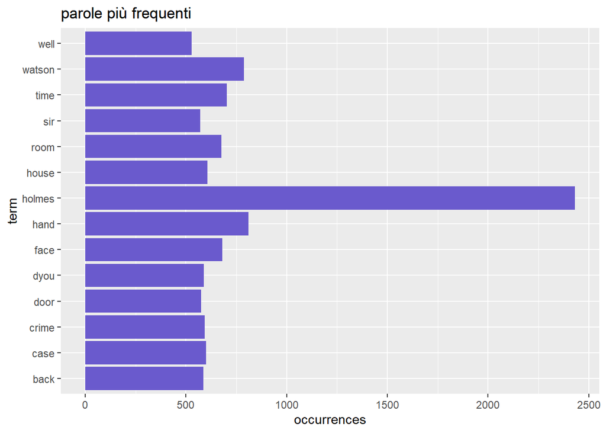

```r
library(ggplot2)
ggplot(subset(wf, freq > 500), aes(term, occurrences)) +
  geom_bar(stat = 'identity', fill = 'slateblue') +
  coord_flip() +
  labs(title = 'parole più frequenti')
```

Come precedentemente detto, il termine con maggiore frequenza è holmes, che appare quasi 3 volte in più della seconda parola più frequente; mi aspetto pertanto che, nella successiva clusterizzazione, possa apparire come cluster a sé.

Di seguito un altro grafico per le parole più frequenti, questa volta con wordcloud da cui si evince ancor più chiaramente quanto già detto per la parola holmes.

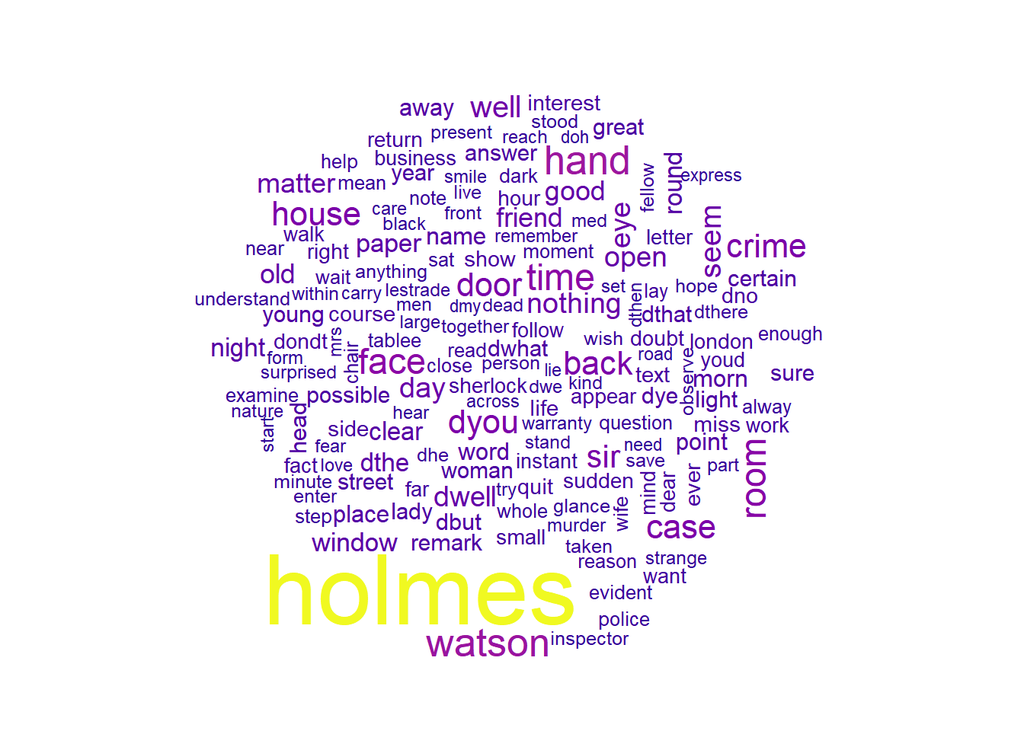

```r
library(wordcloud)
wordcloud(names(freq), freq, min.freq = 160, colors = viridis::plasma(100))
```

Dal wordcloud vediamo che, a parte holmes e watson, che comunque sono i protagonisti della storia quindi chiaramente sono due delle parole più dette, molte delle parole rimandano a quello che sherlock holmes fa di mestiere cioè l’investigatore come ad esempio crime, case, inspector. Poi abbiamo alcune parole legate al tempo come time e instant, alcune parole legate ai luoghi e alle persone che sherlock spesso descrive e come abbiamo già detto abbiamo lasciato un po’ di parole che ci sembravano potessero far capire a chi legge in che posto (london) e in che momento è ambientata la storia, come tutte le parole che nell’inglesse corrente hanno perso la d iniziale (ad esempio dbut).

```r
new_document_term <- document_term[, names(mfw)]
matrix_tdm <- as.matrix(t(new_document_term))
```

Definiamo i cluster cominciando con il clustering gerarchico e ne rappresentiamo il dendogramma derivante.

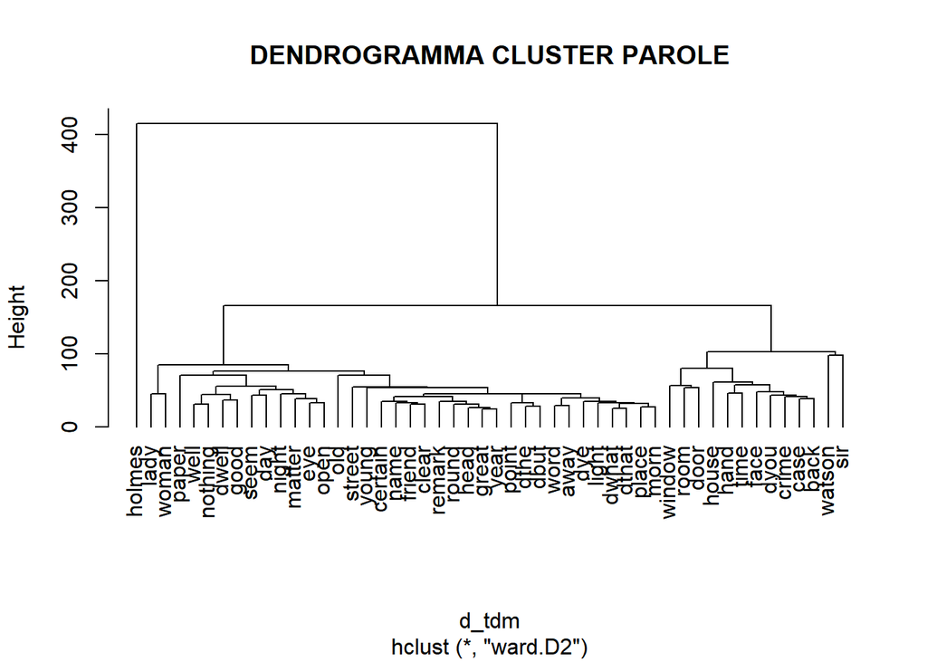

```r
d_tdm <- dist(matrix_tdm)
gruppi_tdm <- hclust(d_tdm, method = 'ward.D2')
plot(gruppi_tdm, hang = -1, main = 'DENDROGRAMMA CLUSTER PAROLE')
```

Dividiamo in 4 gruppi e rappresentiamo la suddivisione di seguito.

```r
cutree(gruppi_tdm, 4)
```

```
##  holmes    hand  watson    time    face    room   house    case   crime    dyou
##       1       2       3       2       2       2       2       2       2       2
##    back    door     sir    well    seem nothing     eye     day    open   dwell
##       2       2       3       4       4       4       4       4       4       4
##  matter  friend     old    good   paper  window    dthe   night   clear   round
##       4       4       4       4       4       2       4       4       4       4
##   place    word    away    name   point    morn   young    dbut     dye certain
##       4       4       4       4       4       4       4       4       4       4
##    head  remark   dwhat    lady   dthat   woman  street   light   great    year
##       4       4       4       4       4       4       4       4       4       4
```

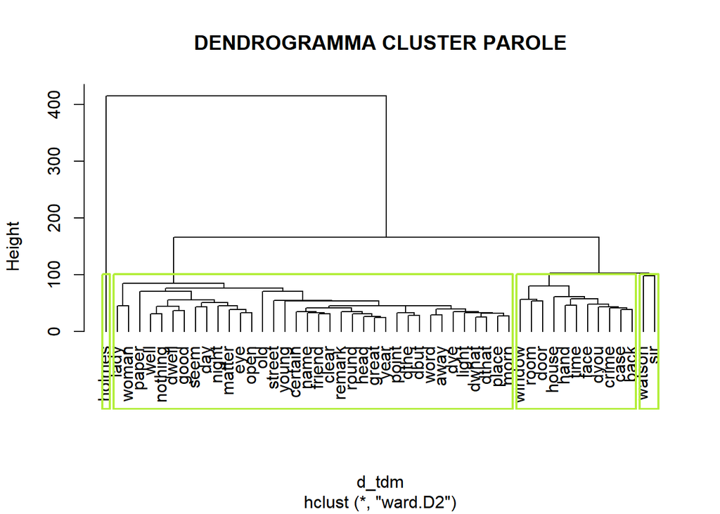

```r
plot(gruppi_tdm, hang = -1, main = 'DENDROGRAMMA CLUSTER PAROLE')
par(lwd = 2)
rect.hclust(gruppi_tdm, k = 4, border = 'olivedrab2')
```

Il clustering gerarchico qui sopra riportato dividendo le parole in quattro cluster riporta due cluster molto meno numerosi degli altri. Se facciamo particolare attenzione uno dei due è il cluster contentente solo la parola holmes, come già supponevamo in precedenza, mentre l’altro riporta le parole watson e sir che comunque erano due delle parole con maggior frequenza.

Facciamo la stessa suddivisione in gruppi anche con il metodo delle K-Medie, con K=4

```r
kfit_tdm <- kmeans(d_tdm, centers = 4, nstart = 2)
```

Rappresentiamo i 4 gruppi con il grafico clusplot.

```r
library(cluster)
library(viridis)
```

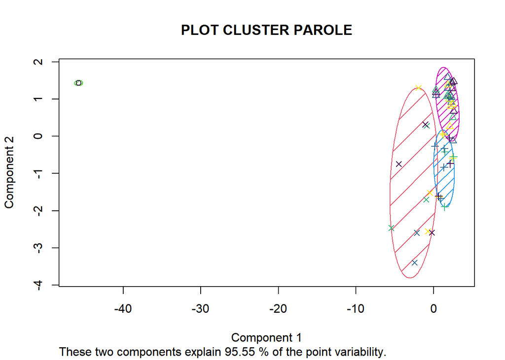

```r
palette <- viridis_pal(option = "D")(length(unique(kfit_tdm$cluster)))
clusplot(as.matrix(d_tdm), kfit_tdm$cluster, color = T, shade = T, labels = 1, lines =            0, col.p = palette, main = 'PLOT CLUSTER PAROLE')
```

```r
par(lwd = 1)
```

Possiamo ben visualizzare come la parola holmes sia ben separata dalle altre anche nella rappresentazione grafica, coerentemente con quanto già succedeva con il clustering gerarchico.

Visualizziamo i centroidi per ogni cluster e, successivamente, la dimensione degli stessi cluster.

```r
print(kfit_tdm)
```

```
## K-means clustering with 4 clusters of sizes 1, 24, 14, 11
##
## Cluster means:
##     holmes      hand    watson      time      face      room     house
## 1   0.0000 253.95078 252.68755 267.77603 271.24712 269.87960 281.06405
## 2 310.3665  77.50437  91.35542  65.01927  62.57168  74.49035  64.48955
## 3 290.3534  62.60149  81.51462  54.05872  50.08871  61.45455  56.45251
## 4 280.9092  62.96569  79.76795  60.33490  58.51903  64.30905  63.58501
##        case     crime      dyou      back      door       sir      well
## 1 275.15268 280.71872 283.11482 280.00536 285.18415 284.99825 282.86392
## 2  54.21042  54.28912  52.78397  50.69043  61.10086  82.80300  47.74579
## 3  43.53617  44.22129  43.43262  40.21623  54.82244  78.89249  42.09039
## 4  63.41367  63.06020  60.79758  57.73977  61.89900  79.48499  62.64171
##        seem   nothing       eye       day      open     dwell    matter
## 1 294.26689 287.41955 291.79102 297.81538 293.26780 293.98469 298.71893
## 2  45.42295  40.14784  41.86850  45.62573  39.15717  45.51498  40.36643
## 3  43.27037  37.06111  38.79624  43.80884  37.23409  45.76143  40.66904
## 4  63.09126  59.52696  60.77385  64.72702  58.30215  67.28434  63.67330
##      friend       old      good     paper    window      dthe     night
## 1 297.56680 306.88108 300.53452 301.71013 303.28864 302.18372 302.53925
## 2  36.17434  57.56166  37.43698  58.55204  52.81028  34.13686  44.42764
## 3  40.80557  61.41807  44.18892  61.52593  50.47678  41.98966  44.56935
## 4  61.34780  70.17405  64.44366  72.33105  69.43493  64.78143  66.75952
##       clear     round     place      word      away      name     point
## 1 305.52414 310.11611 311.24267 312.64677 312.99201 309.45921 307.46870
## 2  32.94621  33.50911  33.84905  35.03779  33.42167  35.19069  36.41745
## 3  42.78739  45.08295  45.68396  47.00820  45.88625  47.02666  48.14440
## 4  63.82971  67.26522  66.79558  68.55173  67.80207  69.01590  70.45628
##        morn     young      dbut       dye   certain      head    remark
## 1 307.15794 309.42366 310.85366 309.32022 307.07979 312.49640 314.26581
## 2  32.67873  44.69823  33.07331  35.38158  34.80588  31.39393  35.12831
## 3  42.83178  55.86396  44.11335  47.25509  44.70424  45.40236  48.35380
## 4  66.10539  75.94837  67.70212  69.70271  66.53453  68.23979  71.03586
##       dwhat      lady     dthat     woman    street     light     great
## 1 313.61122 314.62200 314.67602 314.96349 317.12616 316.23725 313.95382
## 2  31.88715  60.42022  31.12721  45.72715  44.59136  34.78403  29.34683
## 3  46.56900  69.56252  45.34445  55.72547  56.15018  48.21171  44.49006
## 4  69.05581  78.39792  68.91689  74.02834  76.57394  70.90081  68.58722
##        year
## 1 317.89621
```

[output cut: 9 more lines]

```
##  matter  friend     old    good   paper  window    dthe   night   clear   round
##       3       2       4       2       4       3       2       3       2       2
##   place    word    away    name   point    morn   young    dbut     dye certain
##       2       2       2       2       2       2       2       2       2       2
##    head  remark   dwhat    lady   dthat   woman  street   light   great    year
##       2       2       2       4       2       2       2       2       2       2
##
## Within cluster sum of squares by cluster:
## [1]      0.00  60251.50  50270.94 124719.22
##  (between_SS / total_SS =  93.3 %)
##
## Available components:
##
## [1] "cluster"      "centers"      "totss"        "withinss"     "tot.withinss"
## [6] "betweenss"    "size"         "iter"         "ifault"
```

```r
kfit_tdm$size
```

```
## [1]  1 24 14 11
```

La divisione con k-medie riporta 4 gruppi composti rispettivamente da 1, 24, 14, 11 parole.

Passiamo ora ad analizzare i documenti, creando una riprendendo la Document-Term matrix, cioè una matrice con i documenti come righe e i termini come colonne.

```r
inspect(new_document_term[1:3, 1:4])
```

```
## <<DocumentTermMatrix (documents: 3, terms: 4)>>
## Non-/sparse entries: 12/0
## Sparsity           : 0%
## Maximal term length: 6
## Weighting          : term frequency (tf)
## Sample             :
##                           Terms
## Docs                       hand holmes time watson
##   A Case of Identity.txt      9     46    6      4
##   A Scandal in Bohemia.txt   17     48   10      6
##   His Last Bow.txt            8     21   10     16
```

```r
matrix_dtm <- as.matrix(new_document_term)
```

Eseguiamo le stesse analisi fatte in precedenza per fare questa volta un clustering dei documenti e non delle parole. Abbiamo ritenuto opportuno fare 5 cluster, dal momento che i libri erano suddivisi in 5 macrostorie, di seguito la rappresentazione del clustering gerarchico.

[output not shown]

[output cut: 57 more lines]

```
##                                                3
##                             The Naval Treaty.txt
##                                                5
##                   The Problem of Thor Bridge.txt
##                                                4
##                        The Red-Headed League.txt
##                                                1
##                          The Reigate Squires.txt
##                                                4
##                         The Resident Patient.txt
##                                                1
##                     The Stock-Broker’s Clerk.txt
##                                                3
##                              The Yellow Face.txt
##                                                3
```

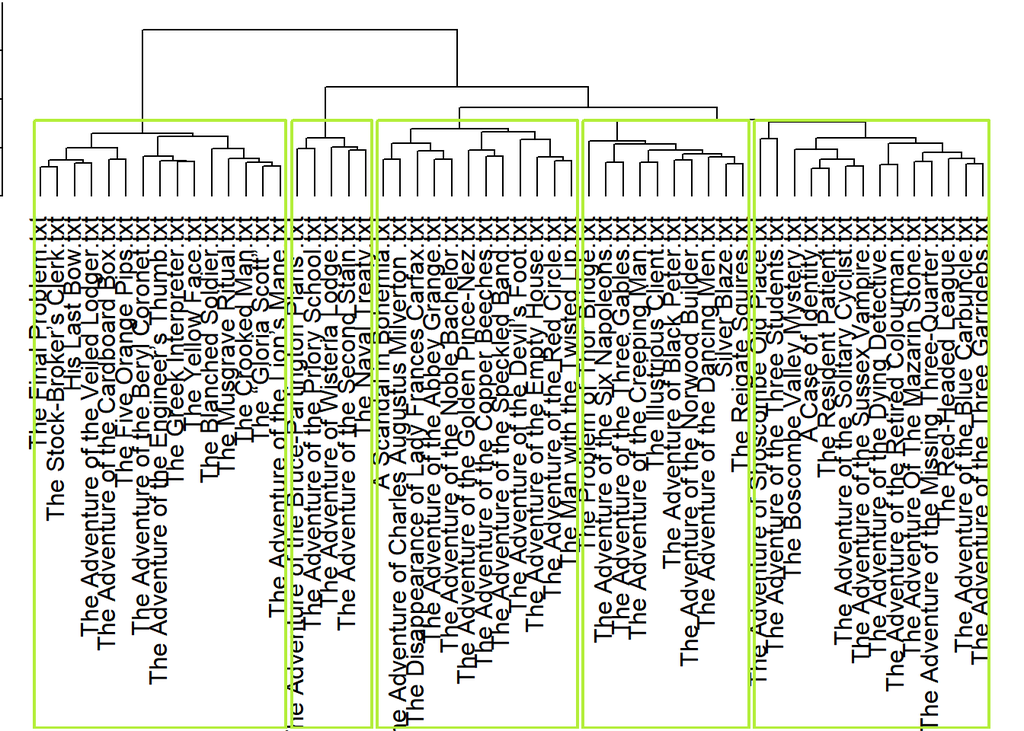

Il clustering gerarchico ci restituisce 4 cluster abbastanza numerosi e uno abbastanza meno numeroso degli altri.

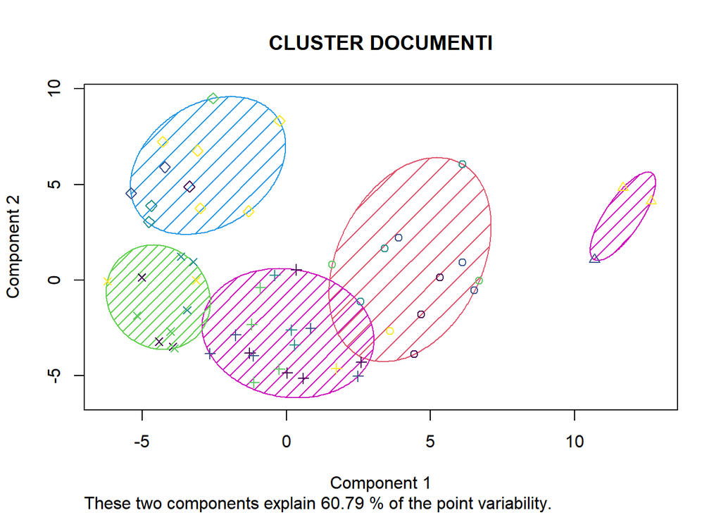

```r
kfit_dtm <- kmeans(d_dtm, centers = 5, nstart = 2)

par(mfrow=c(1,1), mar = c(5.1, 4.1, 4.1, 2.1))

library(viridis)
palette <- viridis_pal(option = "D")(length(unique(kfit_dtm$cluster)))
clusplot(as.matrix(d_dtm), kfit_dtm$cluster, color = T, shade = T, labels = 1,
         lines = 0, col.p = palette, main = 'CLUSTER DOCUMENTI')
```

```r
par(lwd = 1)
```

```r
print(kfit_dtm)
```

```
## K-means clustering with 5 clusters of sizes 12, 3, 18, 12, 11
##
## Cluster means:
##   A Case of Identity.txt A Scandal in Bohemia.txt His Last Bow.txt
## 1               54.61952                 54.66142         65.04923
## 2               70.35810                 61.64153         85.72514
## 3               42.41319                 42.74800         52.26081
## 4               35.13927                 41.65433         41.04402
## 5               49.21323                 53.85391         38.85645
##   Silver Blaze.txt The “Gloria Scott”.txt The Adventure of Black Peter.txt
## 1         50.23319               71.75502                         49.93348
## 2         56.06164               91.45454                         58.32082
## 3         38.75456               59.39624                         39.91196
## 4         42.75330               45.12128                         46.36634
## 5         53.44073               34.84300                         56.73697
##   The Adventure of Charles Augustus Milverton .txt
## 1                                         54.13022
## 2                                         58.53880
## 3                                         44.37953
## 4                                         47.59201
## 5                                         59.94176
##   The Adventure of Shoscombe Old Place.txt
## 1                                 62.22378
## 2                                 78.25341
## 3                                 63.02636
## 4                                 65.47094
## 5                                 71.92109
##   The Adventure of the Abbey Grange.txt The Adventure of the Beryl Coronet.txt
## 1                              51.95965                               62.13350
## 2                              65.14696                               73.08455
## 3                              44.68390                               55.34383
## 4                              43.86249                               48.27275
## 5                              53.84820                               44.84837
##   The Adventure of the Blue Carbuncle.txt
## 1                                54.12913
## 2                                67.61281
## 3                                42.26279
## 4                                34.93925
## 5                                45.57299
##   The Adventure of the Bruce-Partington Plans .txt
```

[output cut: 269 more lines]

```
##                         The Resident Patient.txt
##                                                4
##                     The Stock-Broker’s Clerk.txt
##                                                4
##                              The Yellow Face.txt
##                                                5
##
## Within cluster sum of squares by cluster:
## [1] 62072.939  7606.894 60043.094 29824.798 35374.054
##  (between_SS / total_SS =  57.2 %)
##
## Available components:
##
## [1] "cluster"      "centers"      "totss"        "withinss"     "tot.withinss"
## [6] "betweenss"    "size"         "iter"         "ifault"
```

```r
kfit_dtm$size
```

```
## [1] 12  3 18 12 11
```

## CONCLUSIONE

In conclusione, dalle nostre analisi possiamo evincere come i due metodi di analisi del dataset forniscano risultati simili, ma non uguali. Con il mondo Tidyverse la parola più frequente è ‘holmes’, seguita a breve distanza da ‘sir’, la quale appare quasi esclusivamente in ‘The Hound of the Baskervilles’, e più staccate troviamo ‘time’ ‘watson’ e altre. Con l’analisi del corpus tramite Document-Term c’è sempre ‘holmes’ al primo posto, qui con una frequenza notevolmente maggiore rispetto alle successive ‘hand’ e ‘watson’. Altre considerazioni riguardano il clustering dei documenti, il quale ha portato a risultati meno soddisfacenti rispetto a quello delle parole, ma ciò deriva per larga parte dalla natura delle collezioni, le quali non sono state costruite in base all’argomento.